# Cyclistic Case Study - Visualizations

Brian Rosseau

2023-07-15

### 1. Load cleaned data set and packages

```r
total_tripdata_clean_5 <- read.csv("C:\\Users\\rosse\\OneDrive\\Documents\\Google Data Analytics\\Case Study - Bicycle Data\\07-05-23 total_tripdata_clean_5.csv")
```

```r
library(tidyverse)
library(data.table)
library(viridis)
library(ggpubr)
library(leaflet)
library(scales)
```

### 2. Most popular stations

#### All stations, by number of rides

This map shows all the start stations, distinguishing them by total number of rides

```r
#Create a map to show the most popular stations by all riders
map_data <- total_tripdata_clean_5 %>%
  select(
    start_station_name,
    start_lat,
    start_lng
  ) %>%
  group_by(
    start_station_name
  ) %>%
  mutate(
    numrides = n()
  ) %>%
  distinct(
    start_station_name,
    .keep_all = TRUE
  )

ride_bins <- seq(0, 80000, by = 10000)

ride_palette <- colorBin(
  palette = "plasma"(15, direction = -1),
  domain = map_data$numrides,
  na.color = "transparent",
  bins = ride_bins
  )

ride_text <- paste(
  "Station name: ", map_data$start_station_name, "<br/>",
  "Number of rides: ", map_data$numrides, sep = ""
  ) %>%
  lapply(htmltools::HTML)

plot_station_map <- leaflet(map_data) %>%
  addTiles() %>%

  setView(
    lng = -87.6298, lat = 41.8781, zoom = 11.5
  ) %>%

  addProviderTiles("Esri.WorldImagery") %>%

  addCircleMarkers(
    ~ start_lng, ~ start_lat,
    fillColor = ~ ride_palette(numrides),
    fillOpacity = 0.7,
    color = "white",
    radius = 7,
    stroke = FALSE,
    label = ride_text,
    labelOptions = labelOptions(
      style = list(
        "font-weight" = "normal",
        padding = "3px 8px"
        ),
      textsize = "13px",
      direction = "auto"
      )
    ) %>%

  addLegend(
    pal = ride_palette,
    values = ~ numrides,
    opacity = 0.9,
    title = "Number of rides",
    position = "bottomright"
    )

plot_station_map
```

[interactive chart not shown]

#### Top 20 Casual Stations

This map filters out the start stations with the most number of rides by casual users.

```r
#Create a map of the top 20 casual stations
map_data_casual <- total_tripdata_clean_5 %>%        # Data frame name reflects casual riders
  filter(                                            # Add filter for casual riders
    member_casual == "casual"
  ) %>%
  select(
    start_station_name,
    start_lat,
    start_lng
  ) %>%
  group_by(
    start_station_name
  ) %>%
   mutate(
    numrides = n()
  ) %>%
  distinct(
    start_station_name,
    .keep_all = TRUE
  ) %>%
  arrange(                                            #Add arrange and head lines to limit top 20 n
    desc(numrides)
  ) %>%
  head(n = 20)

ride_bins <- seq(10000, 55000, by = 5000)

ride_palette <- colorBin(
  palette = "plasma"(15, direction = -1),
  domain = map_data_casual$numrides,
  na.color = "transparent",
  bins = ride_bins
  )

ride_text <- paste(
  "Station name: ", map_data_casual$start_station_name, "<br/>",
  "Customer type: ", "Casual riders", "<br/>",                                   # Add text line for casual
  "Number of rides: ", map_data_casual$numrides, sep = ""
  ) %>%
  lapply(htmltools::HTML)

plot_station_map_casual <- leaflet(map_data_casual) %>%
  addTiles() %>%

  setView(
    lng = -87.6298, lat = 41.9081, zoom = 11.5
  ) %>%

  addProviderTiles("Esri.WorldImagery") %>%

  addCircleMarkers(
    ~ start_lng, ~ start_lat,
    fillColor = ~ ride_palette(numrides),
    fillOpacity = 0.7,
    color = "white",
    radius = 7,
    stroke = FALSE,
    label = ride_text,
    labelOptions = labelOptions(
      style = list(
        "font-weight" = "normal",
        padding = "3px 8px"
        ),
      textsize = "13px",
      direction = "auto"
      )
    ) %>%

  addLegend(
    pal = ride_palette,
    values = ~ numrides,
    opacity = 0.9,
    title = "Number of rides",
    position = "bottomright"
    )

  #labs(title = "Top 20 Stations for Casual Riders")

plot_station_map_casual
```

[interactive chart not shown]

```r
#Create a list of the top 20 casual stations
popular_stations_casual <- total_tripdata_clean_5 %>%
  filter(
    member_casual == "casual"
  ) %>%
  group_by(
    start_station_name, member_casual
  ) %>%
  summarise(
    .groups = "keep", number_of_casual_rides = n()
  ) %>%
  arrange(
    desc(number_of_casual_rides)
  )

head(popular_stations_casual, n = 20)
```

| start_station_name | member_casual | number_of_casual_rides |
| --- | --- | --- |
| Streeter Dr & Grand Ave | casual | 54394 |
| DuSable Lake Shore Dr & Monroe St | casual | 30470 |
| Millennium Park | casual | 23975 |
| Michigan Ave & Oak St | casual | 23436 |
| DuSable Lake Shore Dr & North Blvd | casual | 21949 |
| Shedd Aquarium | casual | 19283 |
| Theater on the Lake | casual | 17243 |
| Wells St & Concord Ln | casual | 14820 |
| Dusable Harbor | casual | 13243 |
| Clark St & Armitage Ave | casual | 12753 |

[output cut: 10 more lines]

#### Top 20 Member Stations

This map filters out the start stations with the most number of rides by members.

```r
#Create a map of the top 20 member stations
map_data_member <- total_tripdata_clean_5 %>%        # Data frame name reflects members
  filter(                                            # Add filter for members
    member_casual == "member"
  ) %>%
  select(
    start_station_name,
    start_lat,
    start_lng
  ) %>%
  group_by(
    start_station_name
  ) %>%
  mutate(
    numrides = n()
  ) %>%
  distinct(
    start_station_name,
    .keep_all = TRUE
  ) %>%
  arrange(                                            #Add arrange and head lines to limit top 20 n
    desc(numrides)
  ) %>%
  head(n = 20)

ride_bins <- seq(14000, 26000, by = 2000)

ride_palette <- colorBin(
  palette = "plasma"(15, direction = -1),
  domain = map_data_member$numrides,
  na.color = "transparent",
  bins = ride_bins
  )

ride_text <- paste(
  "Station name: ", map_data_member$start_station_name, "<br/>",
  "Customer type: ", "Members", "<br/>",                                   # Add text line for members
  "Number of rides: ", map_data_member$numrides, sep = ""
  ) %>%
  lapply(htmltools::HTML)


plot_station_map_member <- leaflet(map_data_member) %>%
  addTiles() %>%

  setView(
    lng = -87.6298, lat = 41.8681, zoom = 11.4
  ) %>%

  addProviderTiles(
    "Esri.WorldImagery"
  ) %>%

  addCircleMarkers(
    ~ start_lng, ~ start_lat,
    fillColor = ~ ride_palette(numrides),
    fillOpacity = 0.7,
    color = "white",
    radius = 7,
    stroke = FALSE,
    label = ride_text,
    labelOptions = labelOptions(
      style = list(
        "font-weight" = "normal",
        padding = "3px 8px"
        ),
      textsize = "13px",
      direction = "auto"
      )
    ) %>%

  addLegend(
    pal = ride_palette,
    values = ~ numrides,
    opacity = 0.9,
    title = "Number of rides",
    position = "bottomright"
    )

plot_station_map_member
```

[interactive chart not shown]

```r
#Create a list of the top 20 members stations
popular_stations_member <- total_tripdata_clean_5 %>%
  filter(
    member_casual == "member"
  ) %>%
  group_by(
    start_station_name, member_casual
  ) %>%
  summarise(
    .groups = "keep", number_of_member_rides = n()
  ) %>%
  arrange(
    desc(number_of_member_rides)
  )

head(popular_stations_member, n = 20)
```

| start_station_name | member_casual | number_of_member_rides |
| --- | --- | --- |
| Kingsbury St & Kinzie St | member | 24023 |
| Clark St & Elm St | member | 20872 |
| Wells St & Concord Ln | member | 20010 |
| Clinton St & Washington Blvd | member | 18713 |
| Clinton St & Madison St | member | 18275 |
| Loomis St & Lexington St | member | 18055 |
| Wells St & Elm St | member | 17744 |
| University Ave & 57th St | member | 17264 |
| Ellis Ave & 60th St | member | 17250 |
| Broadway & Barry Ave | member | 16035 |

[output cut: 10 more lines]

#### Top 20 Stations Overall

Now, let’s identify the top 20 stations overall, putting an * by the ones that appear on both the Top 20 Casual Stations list and Top 20 Member Stations list.

```r
#Most popular stations overall.

#First, create a data frame with the most popular start stations overall (highest number of total rides)
popular_stations_overall <- total_tripdata_clean_5 %>%
  group_by(
    start_station_name
  ) %>%
  summarise(
    number_of_total_rides = n()
  ) %>%
  arrange(
    desc(number_of_total_rides)
  )

#Join columns from the popular_stations_casual and popular_stations_member data frames
popular_stations_combined <- popular_stations_overall %>%
  left_join(popular_stations_casual, by = "start_station_name") %>%
  subset(select = -c(member_casual)) %>%
  left_join(popular_stations_member, by = "start_station_name") %>%
  subset(select = -c(member_casual)) %>%
  head(popular_stations_combined, n = 20) #%>%   highlight(sel = c(1,3,5,6,10,12,13))

#Create a column that identifies ("*") the the stations that are on both the Top 20 Casual Stations and Top 20 Member Stations lists.
popular_stations_combined$both <- with(popular_stations_combined, ifelse(
    number_of_casual_rides >= 10552
    &
    number_of_member_rides >= 14378,
    "*", "")
  )

popular_stations_combined <- popular_stations_combined %>%
     relocate(both, .after = start_station_name)

popular_stations_combined
```

| start_station_name | both | number_of_total_rides | number_of_casual_rides | number_of_member_rides |
| --- | --- | --- | --- | --- |
| Streeter Dr & Grand Ave | * | 70281 | 54394 | 15887 |
| DuSable Lake Shore Dr & Monroe St |  | 39447 | 30470 | 8977 |
| DuSable Lake Shore Dr & North Blvd | * | 37331 | 21949 | 15382 |
| Michigan Ave & Oak St |  | 36755 | 23436 | 13319 |
| Wells St & Concord Ln | * | 34830 | 14820 | 20010 |
| Clark St & Elm St | * | 32881 | 12009 | 20872 |
| Millennium Park |  | 32754 | 23975 | 8779 |
| Kingsbury St & Kinzie St |  | 32010 | 7987 | 24023 |
| Theater on the Lake |  | 31033 | 17243 | 13790 |
| Wells St & Elm St | * | 29346 | 11602 | 17744 |

[output cut: 10 more lines]

We should market these stations, especially those marked with an *.

### 3. Most popular times of the year - Heatmap

Let’s create a heatmap that shows us the most popular times of the year for all riders, by number of rides.

```r
#Arrange days of week in order beginning with Monday
total_tripdata_clean_5$day_of_week <- ordered(
  total_tripdata_clean_5$day_of_week,
  levels = c(
    "Monday", "Tuesday", "Wednesday", "Thursday", "Friday", "Saturday", "Sunday"
  )
)

#Create a data frame summarizes the number of rides by date
heat_map_data <- total_tripdata_clean_5 %>%
  select(
    date,
    day_of_week,
    week,
    year
    ) %>%
  group_by(
    date
    ) %>%
  mutate(
    numrides = n()
    ) %>%
  distinct(
    date,
    .keep_all = TRUE
    )
```

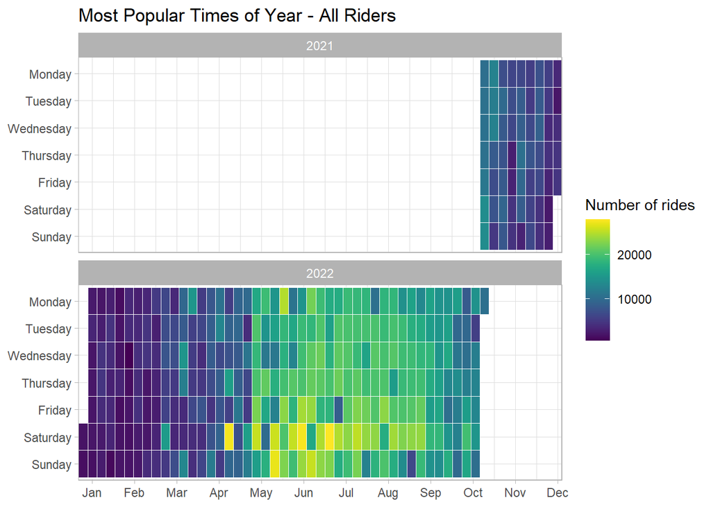

```r
#Create a heat map to show the most popular times of the year for all riders
plot_heat_map <- ggplot(
  heat_map_data,
  aes(
    x = week,
    y = day_of_week,
    fill = numrides
    )
  ) +
  scale_fill_viridis(
    option = "D",
    direction = 1,
    name = "Number of rides"
    ) +
  geom_tile(
    color = "white",
    na.rm = FALSE
    ) +
  facet_wrap(
    "year",
    ncol = 1
    ) +
  scale_y_discrete(
    limits = rev
    ) +
  scale_x_continuous(
    expand = c(0,0),
    breaks = seq(1, 52, length = 12),
    labels = c("Jan", "Feb", "Mar", "Apr", "May", "Jun", "Jul", "Aug", "Sep", "Oct", "Nov", "Dec")
    ) +
  theme_light() +
  theme(
    axis.title = element_blank()
    ) +
  labs(title = "Most Popular Times of Year - All Riders")

plot_heat_map
```

We can see that the summer months are considerably more popular among all riders.

Now, let’s break this down into two separate heat maps - one for casual riders and one for members.

```r
#Create a data frame that summarizes the number of rides by date and type of rider
heat_map_data_member_casual <- total_tripdata_clean_5 %>%

  select(
    date,
    day_of_week,
    week,
    year,
    member_casual,
  ) %>%

  group_by(
    member_casual,
    date
  ) %>%

  mutate(
    numrides = n()
  ) %>%

  distinct(
    date,
    member_casual,
    .keep_all = TRUE
  )

#Create data frame for casual riders
casual_heat_map <- heat_map_data_member_casual %>%
  filter(member_casual == "casual")

#Create data frame for members
member_heat_map <- heat_map_data_member_casual %>%
  filter(member_casual == "member")
```

```r
head(heat_map_data_member_casual)
```

| date | day_of_week | week | year | member_casual | numrides |
| --- | --- | --- | --- | --- | --- |
| 2021-11-01 | Monday | 44 | 2021 | casual | 2572 |
| 2021-11-01 | Monday | 44 | 2021 | member | 7861 |
| 2021-11-02 | Tuesday | 44 | 2021 | member | 8298 |
| 2021-11-02 | Tuesday | 44 | 2021 | casual | 2297 |
| 2021-11-03 | Wednesday | 44 | 2021 | casual | 2325 |
| 2021-11-03 | Wednesday | 44 | 2021 | member | 8342 |

```r
head(casual_heat_map)
```

| date | day_of_week | week | year | member_casual | numrides |
| --- | --- | --- | --- | --- | --- |
| 2021-11-01 | Monday | 44 | 2021 | casual | 2572 |
| 2021-11-02 | Tuesday | 44 | 2021 | casual | 2297 |
| 2021-11-03 | Wednesday | 44 | 2021 | casual | 2325 |
| 2021-11-04 | Thursday | 44 | 2021 | casual | 2486 |
| 2021-11-05 | Friday | 44 | 2021 | casual | 3543 |
| 2021-11-06 | Saturday | 44 | 2021 | casual | 6146 |

```r
head(member_heat_map)
```

| date | day_of_week | week | year | member_casual | numrides |
| --- | --- | --- | --- | --- | --- |
| 2021-11-01 | Monday | 44 | 2021 | member | 7861 |
| 2021-11-02 | Tuesday | 44 | 2021 | member | 8298 |
| 2021-11-03 | Wednesday | 44 | 2021 | member | 8342 |
| 2021-11-04 | Thursday | 44 | 2021 | member | 8161 |
| 2021-11-05 | Friday | 44 | 2021 | member | 7860 |
| 2021-11-06 | Saturday | 44 | 2021 | member | 7649 |

```r
#Create heat map for casual riders
plot_heat_map_casual <- ggplot(
  casual_heat_map,
  aes(
    x = week,
    y = day_of_week,
    fill = numrides
  )
) +

  scale_fill_viridis(
    option = "C",
    direction = 1,
    name = "Number of rides"
  ) +

  geom_tile(
    color = "white",
    na.rm = FALSE
  ) +

  facet_wrap(
    "year",
    ncol = 1
  ) +

  scale_y_discrete(
    limits = rev
  ) +

  scale_x_continuous(
    expand = c(0,0),
    breaks = seq(1, 52, length = 12),
    labels = c("Jan", "Feb", "Mar", "Apr", "May", "Jun", "Jul", "Aug", "Sep", "Oct", "Nov", "Dec")
  ) +

  theme_light() +

  theme(
    axis.title = element_blank()
  ) +

  labs(title = "Casual Riders")
```

```r
#Create heat map for member riders
plot_heat_map_member <- ggplot(
  member_heat_map,
  aes(
    x = week,
    y = day_of_week,
    fill = numrides
  )
) +

  scale_fill_viridis(
    option = "C",
    direction = 1,
    name = "Number of trips"
  ) +

  geom_tile(
    color = "white",
    na.rm = FALSE
  ) +

  facet_wrap(
    "year",
    ncol = 1
  ) +

  scale_y_discrete(
    limits = rev
  ) +

  scale_x_continuous(
    expand = c(0,0),
    breaks = seq(1, 52, length = 12),
    labels = c("Jan", "Feb", "Mar", "Apr", "May", "Jun", "Jul", "Aug", "Sep", "Oct", "Nov", "Dec")
  ) +

  theme_light() +

  theme(
    axis.title = element_blank()
  ) +

  labs(title = "Members")
```

```r
#Combine the heat maps for the casual riders and members, using one legend
plot_heat_map_combined <- ggarrange(
  plot_heat_map_casual,
  plot_heat_map_member,
  ncol = 1,
  nrow = 2,
  common.legend = TRUE,
  legend = "right"
)
```

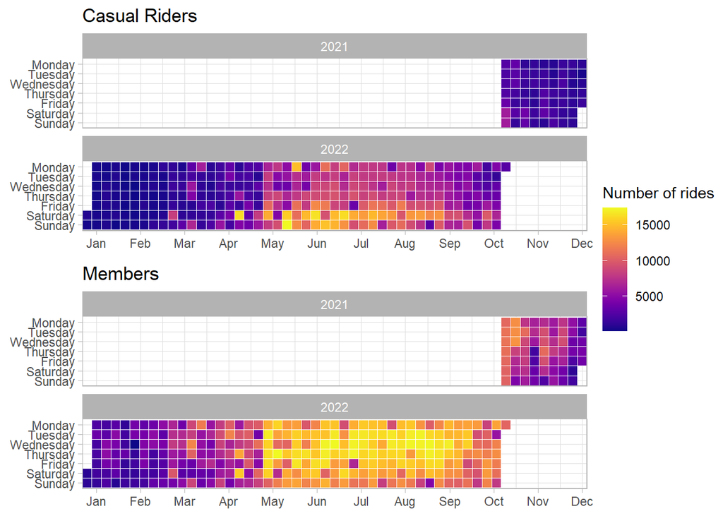

```r
#Plot the combined heat map
plot_heat_map_combined
```

Comparing the two heat maps, we see that members have many more days that have high numbers of rides.

We should focus in on the days that are most popular with casual riders.

### 4. Additional ride data

```r
#Analyze ridership data by type and weekday
total_tripdata_clean_5$day_of_week <- ordered(total_tripdata_clean_5$day_of_week, levels=c("Sunday", "Monday", "Tuesday", "Wednesday", "Thursday", "Friday", "Saturday"))

#Create a tibble that we will use for visualization that calculates number of rides and average duration
vt_num_avg <- total_tripdata_clean_5 %>%
  group_by(member_casual, day_of_week) %>%                  #groups by usertype and weekday
  summarise(
    number_of_rides = n(),
    average_duration_seconds = round(mean(ride_length), 0)
    ) %>%                                         #calculates the number of rides and average duration
  arrange(member_casual, day_of_week)                       #sorts
vt_num_avg
```

| member_casual | day_of_week | number_of_rides | average_duration_seconds |
| --- | --- | --- | --- |
| casual | Sunday | 301285 | 1679 |
| casual | Monday | 210967 | 1537 |
| casual | Tuesday | 191954 | 1330 |
| casual | Wednesday | 199204 | 1282 |
| casual | Thursday | 222413 | 1307 |
| casual | Friday | 245923 | 1378 |
| casual | Saturday | 369307 | 1634 |
| member | Sunday | 296982 | 848 |
| member | Monday | 379113 | 733 |
| member | Tuesday | 406522 | 719 |

[output cut: 4 more lines]

This shows the number of rides and the average duration in seconds, respectively, for casual riders and members each day of the week.

Now we will put Number of Rides in a graph.

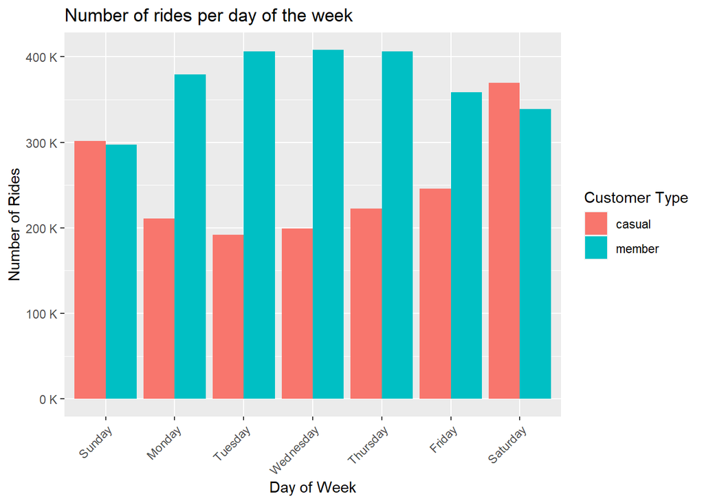

```r
#Visualize the number of rides by rider type
vis_num_rides <- vt_num_avg %>%
  ggplot(aes(x = day_of_week, y = number_of_rides, fill = member_casual)) +
  geom_col(position = "dodge") +
  theme(axis.text.x=element_text(angle = 45, hjust=1)) +
  scale_y_continuous(labels = label_number(suffix = " K", scale = 1e-3)) +
  labs(title = "Number of rides per day of the week",
       x = "Day of Week",
       y = "Number of Rides") +
  scale_fill_discrete(name = "Customer Type")

vis_num_rides
```

This bar graph shows that the number of rides by members far surpasses those by casual riders on Mondays through Fridays. However, casual rides slightly outnumber member rides on the weekends. The most popular days for members are Tuesday, Wednesday, and Thursday

Let’s do the same for Average Ride Length.

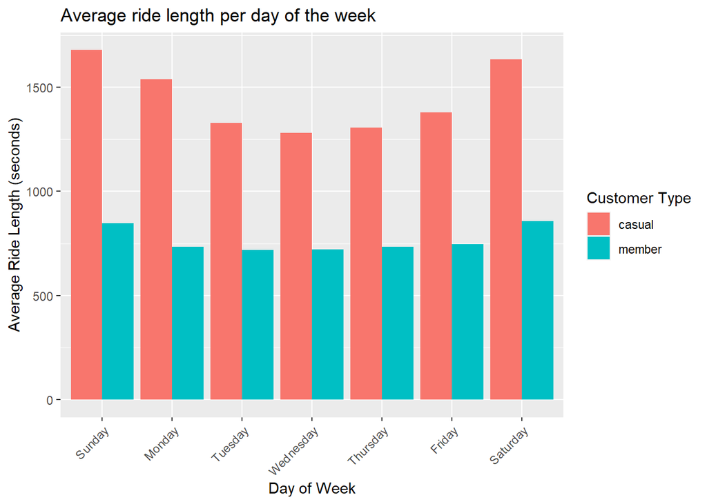

```r
#Visualize average ride duration
vis_avg_dur <- vt_num_avg %>%
  ggplot(aes(x = day_of_week, y = average_duration_seconds, fill = member_casual)) +
  geom_col(position = "dodge") +
  theme(axis.text.x=element_text(angle = 45, hjust=1)) +
  labs(
    title = "Average ride length per day of the week",
    x = "Day of Week",
    y = "Average Ride Length (seconds)") +
  scale_fill_discrete(name = "Customer Type")

vis_avg_dur
```

Now, let’s see if there is any difference in the time of day that casual riders and members use Cyclistic bikes.

```r
#Convert time_of_day from Hour/Minute/Second to 12Hour AM/PM format.
total_tripdata_clean_5$am_pm_hour <-
  format(strptime(total_tripdata_clean_5$time_of_day, '%H:%M:%S'), '%I %p')
```

```r
#Convert am_pm_hour to categorical format to display hours in correct sequence
total_tripdata_clean_5 <- total_tripdata_clean_5 %>%
  mutate(am_pm_hour = factor(am_pm_hour, levels = c("12 AM", "01 AM", "02 AM", "03 AM", "04 AM", "05 AM", "06 AM", "07 AM", "08 AM", "09 AM", "10 AM", "11 AM", "12 PM", "01 PM", "02 PM", "03 PM", "04 PM", "05 PM", "06 PM", "07 PM", "08 PM", "09 PM", "10 PM", "11 PM")))
```

```r
#Create tibble of total number of rides per hour
rides_ph_bar <- total_tripdata_clean_5 %>%
  group_by(member_casual, am_pm_hour) %>%
  summarise(number_of_rides = n()) %>%
  arrange(am_pm_hour)
rides_ph_bar
```

| member_casual | am_pm_hour | number_of_rides |
| --- | --- | --- |
| casual | 12 AM | 32777 |
| member | 12 AM | 24786 |
| casual | 01 AM | 21020 |
| member | 01 AM | 15276 |
| casual | 02 AM | 12728 |
| member | 02 AM | 8389 |
| casual | 03 AM | 7164 |
| member | 03 AM | 5112 |
| casual | 04 AM | 4635 |
| member | 04 AM | 6036 |

[output cut: 38 more lines]

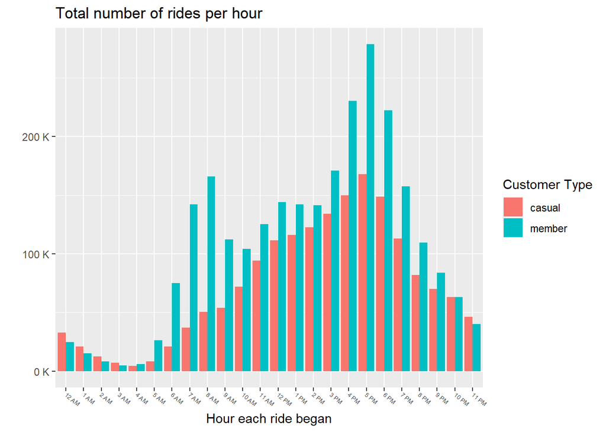

```r
#Visualize total number of rides per hour
rides_ph_bar %>%
  ggplot(aes(x=am_pm_hour, y=number_of_rides, fill=member_casual)) +
  geom_bar(position="dodge", stat="identity") +
  scale_x_discrete(labels = c("12 AM", "1 AM", "2 AM", "3 AM", "4 AM", "5 AM", "6 AM", "7 AM", "8 AM", "9 AM", "10 AM", "11 AM", "12 PM", "1 PM", "2 PM", "3 PM", "4 PM", "5 PM", "6 PM", "7 PM", "8 PM", "9 PM", "10 PM", "11 PM")) +
  labs(
    title = "Total number of rides per hour",
    x = "Hour each ride began",
    y = "") +
  theme(axis.text.x = element_text(size = 5, angle = -40, vjust = 0.5, hjust = 0)) +
  scale_y_continuous(labels = label_number(suffix = " K", scale = 1e-3)) +
  scale_fill_discrete(name = "Customer Type")
```

It appears that start time for member rides peaks at around 8am and 5pm. This would be the times that most people leave for and return from work. The start time for casual riders, however, is around 5pm only. This supports the ideas that members use the bikes mostly for work, and casual riders mostly for recreation, as they are getting off of work.